# Microbiol612+HW1

gwenyu

March 17, 2016

First read in the “gapminder” dataset and load “ggplot” and “plyr” packages that we will be using:

```r
library(plyr)
library("ggplot2")
gapminder <- read.table(file="/Users/WGreene/Practice2/data/gapminder-FiveYearData.csv",sep=',', header=T)
head(gapminder)
```

```
##       country year      pop continent lifeExp gdpPercap
## 1 Afghanistan 1952  8425333      Asia  28.801  779.4453
## 2 Afghanistan 1957  9240934      Asia  30.332  820.8530
## 3 Afghanistan 1962 10267083      Asia  31.997  853.1007
## 4 Afghanistan 1967 11537966      Asia  34.020  836.1971
## 5 Afghanistan 1972 13079460      Asia  36.088  739.9811
## 6 Afghanistan 1977 14880372      Asia  38.438  786.1134
```

For this assignment, I’d like to see if there is relation between GDP per capita and population.

We can directly plot gpdPercap vs. population:

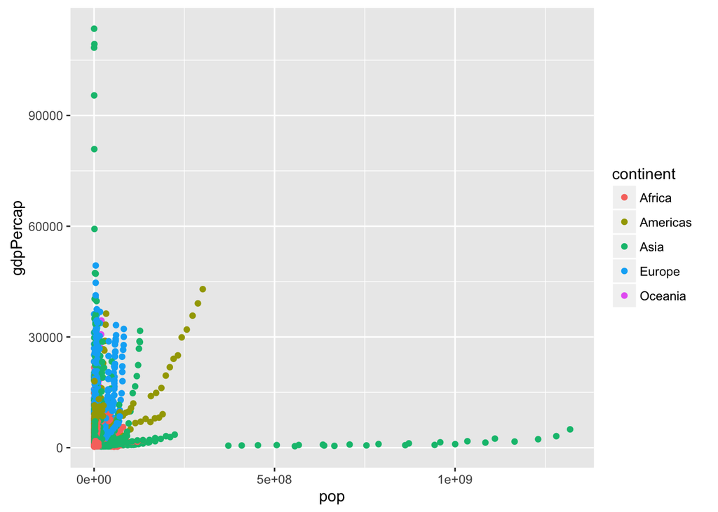

But it dosen’t look very nice. There’re too many points and it’s difficult to see a general trend. So instead, we can combine the data for each continent.

To do this, we can (1) calculate the total population for each continent each year (called tpop), (2) calculate the total GDP by summing “gdpPercap * population” for all countries per continent per year (called tgdp). (3) The averaged gdpPercap for each continent = tgdp / tpop. Combine these data, I made a new table called “summary”.

```r
summary <- ddply(.data = gapminder, .variable = c("continent","year"), summarize, tpop = sum(pop), tgdp = sum(pop * gdpPercap), aveGdp = tgdp/tpop)
```

Now we can plot gdpPercap vs population:

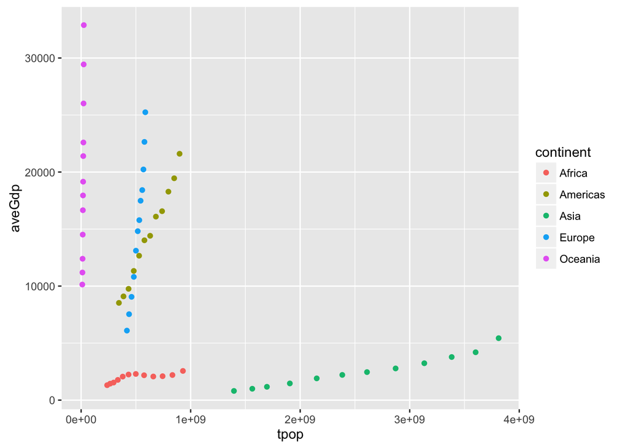

It’s quite clear now that there’s positive correlation between GDP per capita and population. We can fit a simple relationship to the data by adding another layer:

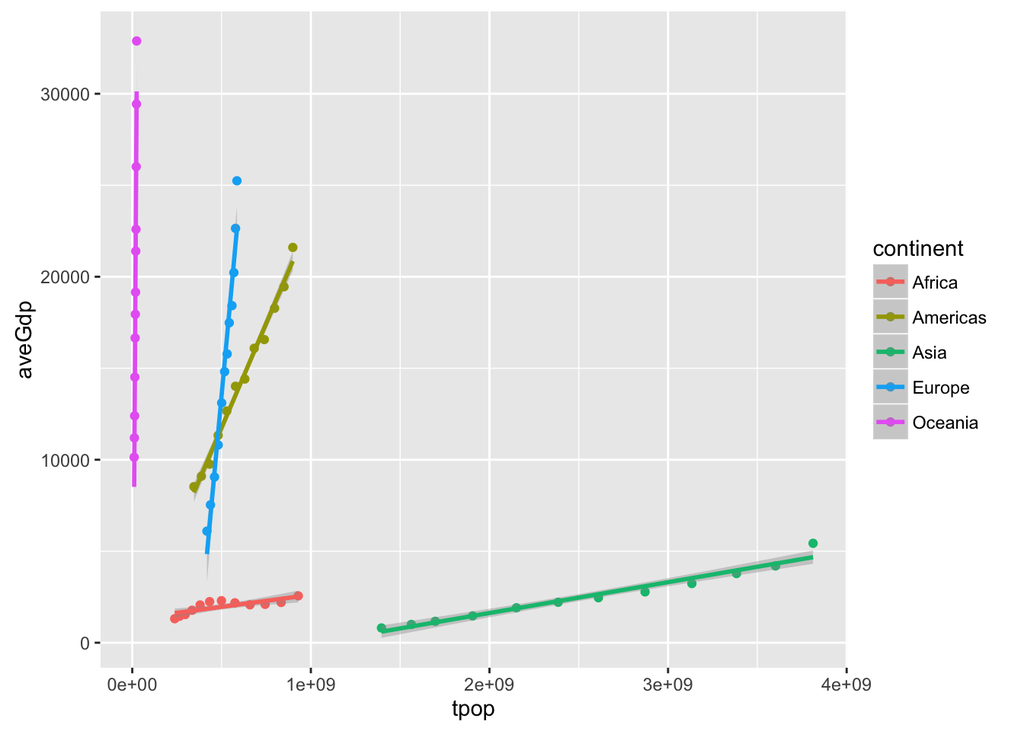

The positive correlation between GDP per capita and population indicates that generally larger population can increases productivity and thus, increases GDP per capita. The slope for Americas, Europe, and Oceania are much steeper than Asia and Africa. For Asia, it may be because that the large population base makes the averaged GDP lower. And for Africa, the unstable political and economical situlation probably affect the GDP largely.